# zipline_example

## zipline installation

Please follow latest instructions [here](https://www.zipline.io/install.html)

It is recommended to install Zipline in an isolated conda environment. Installing Zipline in conda environments will not interfere your default Python deployment or site-packages, which will prevent any possible conflict with your global libraries.

Use the `environment.yml`in this directory to install `zipline` and dependencies in a separate `conda` environment.

```
conda env create -f environment.yml
```

## Ingest Data

Get QUANDL API key and follow instructions to download zipline bundles [here](http://www.zipline.io/bundles.html).

## Imports

```python
import matplotlib.pyplot as plt
import pandas as pd
from zipline.api import order_target, record, symbol
from zipline.examples import buyapple
```

```python
%load_ext zipline
%matplotlib inline
```

## zipline Demo

Zipline is the algorithmic trading library that powers the Quantopian backtesting and live-trading platform. It is also available offline to develop a strategy using a limited number of free data bundles that can be ingested and used to test the performance of trading ideas before porting the result to the online Quantopian platform for paper and live trading.

### Data access using zipline

See `zipline` [docs](http://www.zipline.io/bundles.html) on the download and management of data bundles used to simulate backtests.

The following commandline instruction lists the available bundles (store per default in `~/.zipline`.

```python
!zipline bundles
```

```
csvdir <no ingestions>
quandl 2019-03-06 23:47:31.577436
quandl 2018-06-21 17:47:33.724316
quandl 2018-05-10 14:38:20.063950
quantopian-quandl 2018-06-22 15:46:10.110298
```

The following code illustrates how zipline permits us to access daily stock data for a range of companies. You can run zipline scripts in the Jupyter Notebook using the magic function of the same name.

First, you need to initialize the context with the desired security symbols. We'll also use a counter variable. Then zipline calls handle_data, where we use the `data.history()` method to look back a single period and append the data for the last day to a .csv file:

```python
%%zipline --start 2010-1-1 --end 2018-1-1 --data-frequency daily
from zipline.api import order_target, record, symbol
import pandas as pd

def initialize(context):
    context.i = 0
    context.assets = [symbol('FB'), symbol('GOOG'), symbol('AMZN')]

def handle_data(context, data):
    df = data.history(context.assets, fields=['price', 'volume'], bar_count=1, frequency="1d")
    df = df.to_frame().reset_index()

    if context.i == 0:
        df.columns = ['date', 'asset', 'price', 'volume']
        df.to_csv('stock_data.csv', index=False)
    else:
        df.to_csv('stock_data.csv', index=False, mode='a', header=None)
    context.i += 1
```

```
[2019-04-18 01:09:43.581720] INFO: Loader: Cache at /home/stefan/.zipline/data/SPY_benchmark.csv does not have data from 2010-01-04 00:00:00+00:00 to 2017-12-29 00:00:00+00:00.

[2019-04-18 01:09:43.582187] INFO: Loader: Downloading benchmark data for 'SPY' from 2009-12-31 00:00:00+00:00 to 2017-12-29 00:00:00+00:00
[2019-04-18 01:09:44.252915] WARNING: Loader: Still don't have expected benchmark data for 'SPY' from 2009-12-31 00:00:00+00:00 to 2017-12-29 00:00:00+00:00 after redownload!
```

```
[2019-04-18 01:11:32.638840] INFO: zipline.finance.metrics.tracker: Simulated 2013 trading days
first open: 2010-01-04 14:31:00+00:00
last close: 2017-12-29 21:00:00+00:00
```

|  | algo_volatility | algorithm_period_return | alpha | benchmark_period_return | benchmark_volatility | beta | capital_used | ending_cash | ending_exposure | ending_value | ... | short_exposure | short_value | shorts_count | sortino | starting_cash | starting_exposure | starting_value | trading_days | transactions | treasury_period_return |
| --- | --- | --- | --- | --- | --- | --- | --- | --- | --- | --- | --- | --- | --- | --- | --- | --- | --- | --- | --- | --- | --- |
| 2010-01-04 21:00:00+00:00 | NaN | 0.0 | NaN | 0.003487 | NaN | NaN | 0.0 | 10000000.0 | 0.0 | 0.0 | ... | 0.0 | 0.0 | 0 | None | 10000000.0 | 0.0 | 0.0 | 1 | [] | 0.0 |
| 2010-01-05 21:00:00+00:00 | 0.0 | 0.0 | NaN | 0.006987 | 0.000000 | NaN | 0.0 | 10000000.0 | 0.0 | 0.0 | ... | 0.0 | 0.0 | 0 | None | 10000000.0 | 0.0 | 0.0 | 2 | [] | 0.0 |
| 2010-01-06 21:00:00+00:00 | 0.0 | 0.0 | NaN | 0.010498 | 0.000000 | NaN | 0.0 | 10000000.0 | 0.0 | 0.0 | ... | 0.0 | 0.0 | 0 | None | 10000000.0 | 0.0 | 0.0 | 3 | [] | 0.0 |
| 2010-01-07 21:00:00+00:00 | 0.0 | 0.0 | NaN | 0.014022 | 0.000000 | NaN | 0.0 | 10000000.0 | 0.0 | 0.0 | ... | 0.0 | 0.0 | 0 | None | 10000000.0 | 0.0 | 0.0 | 4 | [] | 0.0 |
| 2010-01-08 21:00:00+00:00 | 0.0 | 0.0 | NaN | 0.017559 | 0.000000 | NaN | 0.0 | 10000000.0 | 0.0 | 0.0 | ... | 0.0 | 0.0 | 0 | None | 10000000.0 | 0.0 | 0.0 | 5 | [] | 0.0 |
| 2010-01-11 21:00:00+00:00 | 0.0 | 0.0 | NaN | 0.021107 | 0.000000 | NaN | 0.0 | 10000000.0 | 0.0 | 0.0 | ... | 0.0 | 0.0 | 0 | None | 10000000.0 | 0.0 | 0.0 | 6 | [] | 0.0 |
| 2010-01-12 21:00:00+00:00 | 0.0 | 0.0 | NaN | 0.024668 | 0.000000 | NaN | 0.0 | 10000000.0 | 0.0 | 0.0 | ... | 0.0 | 0.0 | 0 | None | 10000000.0 | 0.0 | 0.0 | 7 | [] | 0.0 |
| 2010-01-13 21:00:00+00:00 | 0.0 | 0.0 | NaN | 0.028241 | 0.000000 | NaN | 0.0 | 10000000.0 | 0.0 | 0.0 | ... | 0.0 | 0.0 | 0 | None | 10000000.0 | 0.0 | 0.0 | 8 | [] | 0.0 |
| 2010-01-14 21:00:00+00:00 | 0.0 | 0.0 | NaN | 0.031827 | 0.000000 | NaN | 0.0 | 10000000.0 | 0.0 | 0.0 | ... | 0.0 | 0.0 | 0 | None | 10000000.0 | 0.0 | 0.0 | 9 | [] | 0.0 |
| 2010-01-15 21:00:00+00:00 | 0.0 | 0.0 | NaN | 0.035425 | 0.000000 | NaN | 0.0 | 10000000.0 | 0.0 | 0.0 | ... | 0.0 | 0.0 | 0 | None | 10000000.0 | 0.0 | 0.0 | 10 | [] | 0.0 |
| 2010-01-19 21:00:00+00:00 | 0.0 | 0.0 | NaN | 0.039036 | 0.000000 | NaN | 0.0 | 10000000.0 | 0.0 | 0.0 | ... | 0.0 | 0.0 | 0 | None | 10000000.0 | 0.0 | 0.0 | 11 | [] | 0.0 |
| 2010-01-20 21:00:00+00:00 | 0.0 | 0.0 | NaN | 0.042660 | 0.000000 | NaN | 0.0 | 10000000.0 | 0.0 | 0.0 | ... | 0.0 | 0.0 | 0 | None | 10000000.0 | 0.0 | 0.0 | 12 | [] | 0.0 |
| 2010-01-21 21:00:00+00:00 | 0.0 | 0.0 | NaN | 0.046296 | 0.000000 | NaN | 0.0 | 10000000.0 | 0.0 | 0.0 | ... | 0.0 | 0.0 | 0 | None | 10000000.0 | 0.0 | 0.0 | 13 | [] | 0.0 |
| 2010-01-22 21:00:00+00:00 | 0.0 | 0.0 | NaN | 0.049945 | 0.000000 | NaN | 0.0 | 10000000.0 | 0.0 | 0.0 | ... | 0.0 | 0.0 | 0 | None | 10000000.0 | 0.0 | 0.0 | 14 | [] | 0.0 |
| 2010-01-25 21:00:00+00:00 | 0.0 | 0.0 | NaN | 0.053606 | 0.000000 | NaN | 0.0 | 10000000.0 | 0.0 | 0.0 | ... | 0.0 | 0.0 | 0 | None | 10000000.0 | 0.0 | 0.0 | 15 | [] | 0.0 |
| 2010-01-26 21:00:00+00:00 | 0.0 | 0.0 | NaN | 0.057280 | 0.000000 | NaN | 0.0 | 10000000.0 | 0.0 | 0.0 | ... | 0.0 | 0.0 | 0 | None | 10000000.0 | 0.0 | 0.0 | 16 | [] | 0.0 |
| 2010-01-27 21:00:00+00:00 | 0.0 | 0.0 | NaN | 0.060967 | 0.000000 | NaN | 0.0 | 10000000.0 | 0.0 | 0.0 | ... | 0.0 | 0.0 | 0 | None | 10000000.0 | 0.0 | 0.0 | 17 | [] | 0.0 |
| 2010-01-28 21:00:00+00:00 | 0.0 | 0.0 | NaN | 0.064667 | 0.000000 | NaN | 0.0 | 10000000.0 | 0.0 | 0.0 | ... | 0.0 | 0.0 | 0 | None | 10000000.0 | 0.0 | 0.0 | 18 | [] | 0.0 |
| 2010-01-29 21:00:00+00:00 | 0.0 | 0.0 | NaN | 0.068380 | 0.000000 | NaN | 0.0 | 10000000.0 | 0.0 | 0.0 | ... | 0.0 | 0.0 | 0 | None | 10000000.0 | 0.0 | 0.0 | 19 | [] | 0.0 |
| 2010-02-01 21:00:00+00:00 | 0.0 | 0.0 | NaN | 0.072106 | 0.000000 | NaN | 0.0 | 10000000.0 | 0.0 | 0.0 | ... | 0.0 | 0.0 | 0 | None | 10000000.0 | 0.0 | 0.0 | 20 | [] | 0.0 |
| 2010-02-02 21:00:00+00:00 | 0.0 | 0.0 | NaN | 0.075845 | 0.000000 | NaN | 0.0 | 10000000.0 | 0.0 | 0.0 | ... | 0.0 | 0.0 | 0 | None | 10000000.0 | 0.0 | 0.0 | 21 | [] | 0.0 |
| 2010-02-03 21:00:00+00:00 | 0.0 | 0.0 | NaN | 0.079596 | 0.000000 | NaN | 0.0 | 10000000.0 | 0.0 | 0.0 | ... | 0.0 | 0.0 | 0 | None | 10000000.0 | 0.0 | 0.0 | 22 | [] | 0.0 |
| 2010-02-04 21:00:00+00:00 | 0.0 | 0.0 | NaN | 0.083361 | 0.000000 | NaN | 0.0 | 10000000.0 | 0.0 | 0.0 | ... | 0.0 | 0.0 | 0 | None | 10000000.0 | 0.0 | 0.0 | 23 | [] | 0.0 |
| 2010-02-05 21:00:00+00:00 | 0.0 | 0.0 | NaN | 0.087139 | 0.000000 | NaN | 0.0 | 10000000.0 | 0.0 | 0.0 | ... | 0.0 | 0.0 | 0 | None | 10000000.0 | 0.0 | 0.0 | 24 | [] | 0.0 |
| 2010-02-08 21:00:00+00:00 | 0.0 | 0.0 | NaN | 0.090931 | 0.000000 | NaN | 0.0 | 10000000.0 | 0.0 | 0.0 | ... | 0.0 | 0.0 | 0 | None | 10000000.0 | 0.0 | 0.0 | 25 | [] | 0.0 |
| 2010-02-09 21:00:00+00:00 | 0.0 | 0.0 | NaN | 0.094735 | 0.000000 | NaN | 0.0 | 10000000.0 | 0.0 | 0.0 | ... | 0.0 | 0.0 | 0 | None | 10000000.0 | 0.0 | 0.0 | 26 | [] | 0.0 |
| 2010-02-10 21:00:00+00:00 | 0.0 | 0.0 | NaN | 0.098553 | 0.000000 | NaN | 0.0 | 10000000.0 | 0.0 | 0.0 | ... | 0.0 | 0.0 | 0 | None | 10000000.0 | 0.0 | 0.0 | 27 | [] | 0.0 |
| 2010-02-11 21:00:00+00:00 | 0.0 | 0.0 | NaN | 0.102384 | 0.000000 | NaN | 0.0 | 10000000.0 | 0.0 | 0.0 | ... | 0.0 | 0.0 | 0 | None | 10000000.0 | 0.0 | 0.0 | 28 | [] | 0.0 |
| 2010-02-12 21:00:00+00:00 | 0.0 | 0.0 | NaN | 0.106228 | 0.000000 | NaN | 0.0 | 10000000.0 | 0.0 | 0.0 | ... | 0.0 | 0.0 | 0 | None | 10000000.0 | 0.0 | 0.0 | 29 | [] | 0.0 |
| 2010-02-16 21:00:00+00:00 | 0.0 | 0.0 | NaN | 0.110086 | 0.000000 | NaN | 0.0 | 10000000.0 | 0.0 | 0.0 | ... | 0.0 | 0.0 | 0 | None | 10000000.0 | 0.0 | 0.0 | 30 | [] | 0.0 |
| ... | ... | ... | ... | ... | ... | ... | ... | ... | ... | ... | ... | ... | ... | ... | ... | ... | ... | ... | ... | ... | ... |
| 2017-11-16 21:00:00+00:00 | 0.0 | 0.0 | 0.0 | 61.190689 | 0.085431 | 0.0 | 0.0 | 10000000.0 | 0.0 | 0.0 | ... | 0.0 | 0.0 | 0 | None | 10000000.0 | 0.0 | 0.0 | 1984 | [] | 0.0 |
| 2017-11-17 21:00:00+00:00 | 0.0 | 0.0 | 0.0 | 61.007937 | 0.085428 | 0.0 | 0.0 | 10000000.0 | 0.0 | 0.0 | ... | 0.0 | 0.0 | 0 | None | 10000000.0 | 0.0 | 0.0 | 1985 | [] | 0.0 |
| 2017-11-20 21:00:00+00:00 | 0.0 | 0.0 | 0.0 | 61.113759 | 0.085407 | 0.0 | 0.0 | 10000000.0 | 0.0 | 0.0 | ... | 0.0 | 0.0 | 0 | None | 10000000.0 | 0.0 | 0.0 | 1986 | [] | 0.0 |
| 2017-11-21 21:00:00+00:00 | 0.0 | 0.0 | 0.0 | 61.520152 | 0.085400 | 0.0 | 0.0 | 10000000.0 | 0.0 | 0.0 | ... | 0.0 | 0.0 | 0 | None | 10000000.0 | 0.0 | 0.0 | 1987 | [] | 0.0 |
| 2017-11-22 21:00:00+00:00 | 0.0 | 0.0 | 0.0 | 61.464842 | 0.085385 | 0.0 | 0.0 | 10000000.0 | 0.0 | 0.0 | ... | 0.0 | 0.0 | 0 | None | 10000000.0 | 0.0 | 0.0 | 1988 | [] | 0.0 |
| 2017-11-24 18:00:00+00:00 | 0.0 | 0.0 | 0.0 | 61.609129 | 0.085364 | 0.0 | 0.0 | 10000000.0 | 0.0 | 0.0 | ... | 0.0 | 0.0 | 0 | None | 10000000.0 | 0.0 | 0.0 | 1989 | [] | 0.0 |
| 2017-11-27 21:00:00+00:00 | 0.0 | 0.0 | 0.0 | 61.577862 | 0.085347 | 0.0 | 0.0 | 10000000.0 | 0.0 | 0.0 | ... | 0.0 | 0.0 | 0 | None | 10000000.0 | 0.0 | 0.0 | 1990 | [] | 0.0 |
| 2017-11-28 21:00:00+00:00 | 0.0 | 0.0 | 0.0 | 62.212695 | 0.085374 | 0.0 | 0.0 | 10000000.0 | 0.0 | 0.0 | ... | 0.0 | 0.0 | 0 | None | 10000000.0 | 0.0 | 0.0 | 1991 | [] | 0.0 |
| 2017-11-29 21:00:00+00:00 | 0.0 | 0.0 | 0.0 | 62.174230 | 0.085358 | 0.0 | 0.0 | 10000000.0 | 0.0 | 0.0 | ... | 0.0 | 0.0 | 0 | None | 10000000.0 | 0.0 | 0.0 | 1992 | [] | 0.0 |
| 2017-11-30 21:00:00+00:00 | 0.0 | 0.0 | 0.0 | 62.727310 | 0.085369 | 0.0 | 0.0 | 10000000.0 | 0.0 | 0.0 | ... | 0.0 | 0.0 | 0 | None | 10000000.0 | 0.0 | 0.0 | 1993 | [] | 0.0 |
| 2017-12-01 21:00:00+00:00 | 0.0 | 0.0 | 0.0 | 62.595045 | 0.085361 | 0.0 | 0.0 | 10000000.0 | 0.0 | 0.0 | ... | 0.0 | 0.0 | 0 | None | 10000000.0 | 0.0 | 0.0 | 1994 | [] | 0.0 |
| 2017-12-04 21:00:00+00:00 | 0.0 | 0.0 | 0.0 | 62.518090 | 0.085348 | 0.0 | 0.0 | 10000000.0 | 0.0 | 0.0 | ... | 0.0 | 0.0 | 0 | None | 10000000.0 | 0.0 | 0.0 | 1995 | [] | 0.0 |
| 2017-12-05 21:00:00+00:00 | 0.0 | 0.0 | 0.0 | 62.289650 | 0.085350 | 0.0 | 0.0 | 10000000.0 | 0.0 | 0.0 | ... | 0.0 | 0.0 | 0 | None | 10000000.0 | 0.0 | 0.0 | 1996 | [] | 0.0 |
| 2017-12-06 21:00:00+00:00 | 0.0 | 0.0 | 0.0 | 62.301672 | 0.085331 | 0.0 | 0.0 | 10000000.0 | 0.0 | 0.0 | ... | 0.0 | 0.0 | 0 | None | 10000000.0 | 0.0 | 0.0 | 1997 | [] | 0.0 |
| 2017-12-07 21:00:00+00:00 | 0.0 | 0.0 | 0.0 | 62.501269 | 0.085311 | 0.0 | 0.0 | 10000000.0 | 0.0 | 0.0 | ... | 0.0 | 0.0 | 0 | None | 10000000.0 | 0.0 | 0.0 | 1998 | [] | 0.0 |
| 2017-12-08 21:00:00+00:00 | 0.0 | 0.0 | 0.0 | 62.847553 | 0.085298 | 0.0 | 0.0 | 10000000.0 | 0.0 | 0.0 | ... | 0.0 | 0.0 | 0 | None | 10000000.0 | 0.0 | 0.0 | 1999 | [] | 0.0 |
| 2017-12-11 21:00:00+00:00 | 0.0 | 0.0 | 0.0 | 63.039928 | 0.085277 | 0.0 | 0.0 | 10000000.0 | 0.0 | 0.0 | ... | 0.0 | 0.0 | 0 | None | 10000000.0 | 0.0 | 0.0 | 2000 | [] | 0.0 |
| 2017-12-12 21:00:00+00:00 | 0.0 | 0.0 | 0.0 | 63.152948 | 0.085256 | 0.0 | 0.0 | 10000000.0 | 0.0 | 0.0 | ... | 0.0 | 0.0 | 0 | None | 10000000.0 | 0.0 | 0.0 | 2001 | [] | 0.0 |
| 2017-12-13 21:00:00+00:00 | 0.0 | 0.0 | 0.0 | 63.145725 | 0.085238 | 0.0 | 0.0 | 10000000.0 | 0.0 | 0.0 | ... | 0.0 | 0.0 | 0 | None | 10000000.0 | 0.0 | 0.0 | 2002 | [] | 0.0 |
| 2017-12-14 21:00:00+00:00 | 0.0 | 0.0 | 0.0 | 62.883619 | 0.085245 | 0.0 | 0.0 | 10000000.0 | 0.0 | 0.0 | ... | 0.0 | 0.0 | 0 | None | 10000000.0 | 0.0 | 0.0 | 2003 | [] | 0.0 |
| 2017-12-15 21:00:00+00:00 | 0.0 | 0.0 | 0.0 | 63.412333 | 0.085252 | 0.0 | 0.0 | 10000000.0 | 0.0 | 0.0 | ... | 0.0 | 0.0 | 0 | None | 10000000.0 | 0.0 | 0.0 | 2004 | [] | 0.0 |
| 2017-12-18 21:00:00+00:00 | 0.0 | 0.0 | 0.0 | 63.820780 | 0.085244 | 0.0 | 0.0 | 10000000.0 | 0.0 | 0.0 | ... | 0.0 | 0.0 | 0 | None | 10000000.0 | 0.0 | 0.0 | 2005 | [] | 0.0 |
| 2017-12-19 21:00:00+00:00 | 0.0 | 0.0 | 0.0 | 63.571858 | 0.085249 | 0.0 | 0.0 | 10000000.0 | 0.0 | 0.0 | ... | 0.0 | 0.0 | 0 | None | 10000000.0 | 0.0 | 0.0 | 2006 | [] | 0.0 |
| 2017-12-20 21:00:00+00:00 | 0.0 | 0.0 | 0.0 | 63.538019 | 0.085233 | 0.0 | 0.0 | 10000000.0 | 0.0 | 0.0 | ... | 0.0 | 0.0 | 0 | None | 10000000.0 | 0.0 | 0.0 | 2007 | [] | 0.0 |
| 2017-12-21 21:00:00+00:00 | 0.0 | 0.0 | 0.0 | 63.670952 | 0.085211 | 0.0 | 0.0 | 10000000.0 | 0.0 | 0.0 | ... | 0.0 | 0.0 | 0 | None | 10000000.0 | 0.0 | 0.0 | 2008 | [] | 0.0 |
| 2017-12-22 21:00:00+00:00 | 0.0 | 0.0 | 0.0 | 63.654032 | 0.085194 | 0.0 | 0.0 | 10000000.0 | 0.0 | 0.0 | ... | 0.0 | 0.0 | 0 | None | 10000000.0 | 0.0 | 0.0 | 2009 | [] | 0.0 |
| 2017-12-26 21:00:00+00:00 | 0.0 | 0.0 | 0.0 | 63.576682 | 0.085181 | 0.0 | 0.0 | 10000000.0 | 0.0 | 0.0 | ... | 0.0 | 0.0 | 0 | None | 10000000.0 | 0.0 | 0.0 | 2010 | [] | 0.0 |
| 2017-12-27 21:00:00+00:00 | 0.0 | 0.0 | 0.0 | 63.608097 | 0.085162 | 0.0 | 0.0 | 10000000.0 | 0.0 | 0.0 | ... | 0.0 | 0.0 | 0 | None | 10000000.0 | 0.0 | 0.0 | 2011 | [] | 0.0 |
| 2017-12-28 21:00:00+00:00 | 0.0 | 0.0 | 0.0 | 63.741030 | 0.085141 | 0.0 | 0.0 | 10000000.0 | 0.0 | 0.0 | ... | 0.0 | 0.0 | 0 | None | 10000000.0 | 0.0 | 0.0 | 2012 | [] | 0.0 |
| 2017-12-29 21:00:00+00:00 | 0.0 | 0.0 | 0.0 | 63.496932 | 0.085145 | 0.0 | 0.0 | 10000000.0 | 0.0 | 0.0 | ... | 0.0 | 0.0 | 0 | None | 10000000.0 | 0.0 | 0.0 | 2013 | [] | 0.0 |

2013 rows × 37 columns

We can plot the data as follows:

```
asset
Equity(1037 [FB])      AxesSubplot(0.125,0.2;0.775x0.68)
Equity(1244 [GOOG])    AxesSubplot(0.125,0.2;0.775x0.68)
Equity(167 [AMZN])     AxesSubplot(0.125,0.2;0.775x0.68)
Name: price, dtype: object
```

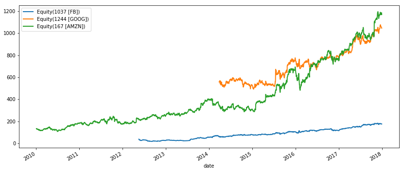

```python
df = pd.read_csv('stock_data.csv')
df.date = pd.to_datetime(df.date)
df.set_index('date').groupby('asset').price.plot(lw=2, legend=True, figsize=(14, 6))
```

### Simple moving average strategy

The following code example illustrates a [Dual Moving Average Cross-Over Strategy](https://www.zipline.io/beginner-tutorial.html#access-to-previous-prices-using-history) to demonstrate zipline in action:

```
[2019-04-18 01:16:39.544889] WARNING: Loader: Refusing to download new benchmark data because a download succeeded at 2019-04-18 01:09:44.248942+00:00.
```

```
[2019-04-18 01:16:42.579180] INFO: zipline.finance.metrics.tracker: Simulated 1007 trading days
first open: 2014-01-02 14:31:00+00:00
last close: 2017-12-29 21:00:00+00:00
```

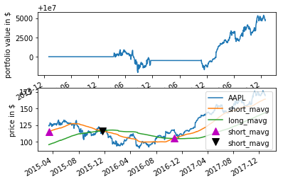

|  | AAPL | algo_volatility | algorithm_period_return | alpha | benchmark_period_return | benchmark_volatility | beta | capital_used | ending_cash | ending_exposure | ... | short_mavg | short_value | shorts_count | sortino | starting_cash | starting_exposure | starting_value | trading_days | transactions | treasury_period_return |
| --- | --- | --- | --- | --- | --- | --- | --- | --- | --- | --- | --- | --- | --- | --- | --- | --- | --- | --- | --- | --- | --- |
| 2014-01-02 21:00:00+00:00 | NaN | NaN | 0.000000 | NaN | 0.003487 | NaN | NaN | 0.0 | 1.000000e+07 | 0.0 | ... | NaN | 0.0 | 0 | NaN | 1.000000e+07 | 0.0 | 0.0 | 1 | [] | 0.0 |
| 2014-01-03 21:00:00+00:00 | NaN | 0.000000 | 0.000000 | NaN | 0.006987 | 0.000000 | NaN | 0.0 | 1.000000e+07 | 0.0 | ... | NaN | 0.0 | 0 | NaN | 1.000000e+07 | 0.0 | 0.0 | 2 | [] | 0.0 |
| 2014-01-06 21:00:00+00:00 | NaN | 0.000000 | 0.000000 | NaN | 0.010498 | 0.000000 | NaN | 0.0 | 1.000000e+07 | 0.0 | ... | NaN | 0.0 | 0 | NaN | 1.000000e+07 | 0.0 | 0.0 | 3 | [] | 0.0 |
| 2014-01-07 21:00:00+00:00 | NaN | 0.000000 | 0.000000 | NaN | 0.014022 | 0.000000 | NaN | 0.0 | 1.000000e+07 | 0.0 | ... | NaN | 0.0 | 0 | NaN | 1.000000e+07 | 0.0 | 0.0 | 4 | [] | 0.0 |
| 2014-01-08 21:00:00+00:00 | NaN | 0.000000 | 0.000000 | NaN | 0.017559 | 0.000000 | NaN | 0.0 | 1.000000e+07 | 0.0 | ... | NaN | 0.0 | 0 | NaN | 1.000000e+07 | 0.0 | 0.0 | 5 | [] | 0.0 |
| 2014-01-09 21:00:00+00:00 | NaN | 0.000000 | 0.000000 | NaN | 0.021107 | 0.000000 | NaN | 0.0 | 1.000000e+07 | 0.0 | ... | NaN | 0.0 | 0 | NaN | 1.000000e+07 | 0.0 | 0.0 | 6 | [] | 0.0 |
| 2014-01-10 21:00:00+00:00 | NaN | 0.000000 | 0.000000 | NaN | 0.024668 | 0.000000 | NaN | 0.0 | 1.000000e+07 | 0.0 | ... | NaN | 0.0 | 0 | NaN | 1.000000e+07 | 0.0 | 0.0 | 7 | [] | 0.0 |
| 2014-01-13 21:00:00+00:00 | NaN | 0.000000 | 0.000000 | NaN | 0.028241 | 0.000000 | NaN | 0.0 | 1.000000e+07 | 0.0 | ... | NaN | 0.0 | 0 | NaN | 1.000000e+07 | 0.0 | 0.0 | 8 | [] | 0.0 |
| 2014-01-14 21:00:00+00:00 | NaN | 0.000000 | 0.000000 | NaN | 0.031827 | 0.000000 | NaN | 0.0 | 1.000000e+07 | 0.0 | ... | NaN | 0.0 | 0 | NaN | 1.000000e+07 | 0.0 | 0.0 | 9 | [] | 0.0 |
| 2014-01-15 21:00:00+00:00 | NaN | 0.000000 | 0.000000 | NaN | 0.035425 | 0.000000 | NaN | 0.0 | 1.000000e+07 | 0.0 | ... | NaN | 0.0 | 0 | NaN | 1.000000e+07 | 0.0 | 0.0 | 10 | [] | 0.0 |
| 2014-01-16 21:00:00+00:00 | NaN | 0.000000 | 0.000000 | NaN | 0.039036 | 0.000000 | NaN | 0.0 | 1.000000e+07 | 0.0 | ... | NaN | 0.0 | 0 | NaN | 1.000000e+07 | 0.0 | 0.0 | 11 | [] | 0.0 |
| 2014-01-17 21:00:00+00:00 | NaN | 0.000000 | 0.000000 | NaN | 0.042660 | 0.000000 | NaN | 0.0 | 1.000000e+07 | 0.0 | ... | NaN | 0.0 | 0 | NaN | 1.000000e+07 | 0.0 | 0.0 | 12 | [] | 0.0 |
| 2014-01-21 21:00:00+00:00 | NaN | 0.000000 | 0.000000 | NaN | 0.046296 | 0.000000 | NaN | 0.0 | 1.000000e+07 | 0.0 | ... | NaN | 0.0 | 0 | NaN | 1.000000e+07 | 0.0 | 0.0 | 13 | [] | 0.0 |
| 2014-01-22 21:00:00+00:00 | NaN | 0.000000 | 0.000000 | NaN | 0.049945 | 0.000000 | NaN | 0.0 | 1.000000e+07 | 0.0 | ... | NaN | 0.0 | 0 | NaN | 1.000000e+07 | 0.0 | 0.0 | 14 | [] | 0.0 |
| 2014-01-23 21:00:00+00:00 | NaN | 0.000000 | 0.000000 | NaN | 0.053606 | 0.000000 | NaN | 0.0 | 1.000000e+07 | 0.0 | ... | NaN | 0.0 | 0 | NaN | 1.000000e+07 | 0.0 | 0.0 | 15 | [] | 0.0 |
| 2014-01-24 21:00:00+00:00 | NaN | 0.000000 | 0.000000 | NaN | 0.057280 | 0.000000 | NaN | 0.0 | 1.000000e+07 | 0.0 | ... | NaN | 0.0 | 0 | NaN | 1.000000e+07 | 0.0 | 0.0 | 16 | [] | 0.0 |
| 2014-01-27 21:00:00+00:00 | NaN | 0.000000 | 0.000000 | NaN | 0.060967 | 0.000000 | NaN | 0.0 | 1.000000e+07 | 0.0 | ... | NaN | 0.0 | 0 | NaN | 1.000000e+07 | 0.0 | 0.0 | 17 | [] | 0.0 |
| 2014-01-28 21:00:00+00:00 | NaN | 0.000000 | 0.000000 | NaN | 0.064667 | 0.000000 | NaN | 0.0 | 1.000000e+07 | 0.0 | ... | NaN | 0.0 | 0 | NaN | 1.000000e+07 | 0.0 | 0.0 | 18 | [] | 0.0 |
| 2014-01-29 21:00:00+00:00 | NaN | 0.000000 | 0.000000 | NaN | 0.068380 | 0.000000 | NaN | 0.0 | 1.000000e+07 | 0.0 | ... | NaN | 0.0 | 0 | NaN | 1.000000e+07 | 0.0 | 0.0 | 19 | [] | 0.0 |
| 2014-01-30 21:00:00+00:00 | NaN | 0.000000 | 0.000000 | NaN | 0.072106 | 0.000000 | NaN | 0.0 | 1.000000e+07 | 0.0 | ... | NaN | 0.0 | 0 | NaN | 1.000000e+07 | 0.0 | 0.0 | 20 | [] | 0.0 |
| 2014-01-31 21:00:00+00:00 | NaN | 0.000000 | 0.000000 | NaN | 0.075845 | 0.000000 | NaN | 0.0 | 1.000000e+07 | 0.0 | ... | NaN | 0.0 | 0 | NaN | 1.000000e+07 | 0.0 | 0.0 | 21 | [] | 0.0 |
| 2014-02-03 21:00:00+00:00 | NaN | 0.000000 | 0.000000 | NaN | 0.079596 | 0.000000 | NaN | 0.0 | 1.000000e+07 | 0.0 | ... | NaN | 0.0 | 0 | NaN | 1.000000e+07 | 0.0 | 0.0 | 22 | [] | 0.0 |
| 2014-02-04 21:00:00+00:00 | NaN | 0.000000 | 0.000000 | NaN | 0.083361 | 0.000000 | NaN | 0.0 | 1.000000e+07 | 0.0 | ... | NaN | 0.0 | 0 | NaN | 1.000000e+07 | 0.0 | 0.0 | 23 | [] | 0.0 |
| 2014-02-05 21:00:00+00:00 | NaN | 0.000000 | 0.000000 | NaN | 0.087139 | 0.000000 | NaN | 0.0 | 1.000000e+07 | 0.0 | ... | NaN | 0.0 | 0 | NaN | 1.000000e+07 | 0.0 | 0.0 | 24 | [] | 0.0 |
| 2014-02-06 21:00:00+00:00 | NaN | 0.000000 | 0.000000 | NaN | 0.090931 | 0.000000 | NaN | 0.0 | 1.000000e+07 | 0.0 | ... | NaN | 0.0 | 0 | NaN | 1.000000e+07 | 0.0 | 0.0 | 25 | [] | 0.0 |
| 2014-02-07 21:00:00+00:00 | NaN | 0.000000 | 0.000000 | NaN | 0.094735 | 0.000000 | NaN | 0.0 | 1.000000e+07 | 0.0 | ... | NaN | 0.0 | 0 | NaN | 1.000000e+07 | 0.0 | 0.0 | 26 | [] | 0.0 |
| 2014-02-10 21:00:00+00:00 | NaN | 0.000000 | 0.000000 | NaN | 0.098553 | 0.000000 | NaN | 0.0 | 1.000000e+07 | 0.0 | ... | NaN | 0.0 | 0 | NaN | 1.000000e+07 | 0.0 | 0.0 | 27 | [] | 0.0 |
| 2014-02-11 21:00:00+00:00 | NaN | 0.000000 | 0.000000 | NaN | 0.102384 | 0.000000 | NaN | 0.0 | 1.000000e+07 | 0.0 | ... | NaN | 0.0 | 0 | NaN | 1.000000e+07 | 0.0 | 0.0 | 28 | [] | 0.0 |
| 2014-02-12 21:00:00+00:00 | NaN | 0.000000 | 0.000000 | NaN | 0.106228 | 0.000000 | NaN | 0.0 | 1.000000e+07 | 0.0 | ... | NaN | 0.0 | 0 | NaN | 1.000000e+07 | 0.0 | 0.0 | 29 | [] | 0.0 |
| 2014-02-13 21:00:00+00:00 | NaN | 0.000000 | 0.000000 | NaN | 0.110086 | 0.000000 | NaN | 0.0 | 1.000000e+07 | 0.0 | ... | NaN | 0.0 | 0 | NaN | 1.000000e+07 | 0.0 | 0.0 | 30 | [] | 0.0 |
| ... | ... | ... | ... | ... | ... | ... | ... | ... | ... | ... | ... | ... | ... | ... | ... | ... | ... | ... | ... | ... | ... |
| 2017-11-16 21:00:00+00:00 | 171.100 | 0.000190 | 0.000485 | 0.000015 | 0.926928 | 0.117531 | 0.000625 | 0.0 | 9.987736e+06 | 17110.0 | ... | 157.284780 | 0.0 | 0 | 0.965631 | 9.987736e+06 | 16908.0 | 16908.0 | 978 | [] | 0.0 |
| 2017-11-17 21:00:00+00:00 | 170.150 | 0.000190 | 0.000475 | 0.000013 | 0.921266 | 0.117485 | 0.000625 | 0.0 | 9.987736e+06 | 17015.0 | ... | 157.533680 | 0.0 | 0 | 0.945566 | 9.987736e+06 | 17110.0 | 17110.0 | 979 | [] | 0.0 |
| 2017-11-20 21:00:00+00:00 | 169.980 | 0.000189 | 0.000473 | 0.000012 | 0.924545 | 0.117426 | 0.000625 | 0.0 | 9.987736e+06 | 16998.0 | ... | 157.802300 | 0.0 | 0 | 0.941682 | 9.987736e+06 | 17015.0 | 17015.0 | 980 | [] | 0.0 |
| 2017-11-21 21:00:00+00:00 | 173.140 | 0.000190 | 0.000505 | 0.000019 | 0.937136 | 0.117404 | 0.000628 | 0.0 | 9.987736e+06 | 17314.0 | ... | 158.099130 | 0.0 | 0 | 1.004008 | 9.987736e+06 | 16998.0 | 16998.0 | 981 | [] | 0.0 |
| 2017-11-22 21:00:00+00:00 | 174.960 | 0.000190 | 0.000523 | 0.000024 | 0.935423 | 0.117347 | 0.000628 | 0.0 | 9.987736e+06 | 17496.0 | ... | 158.419340 | 0.0 | 0 | 1.039651 | 9.987736e+06 | 17314.0 | 17314.0 | 982 | [] | 0.0 |
| 2017-11-24 18:00:00+00:00 | 174.970 | 0.000190 | 0.000523 | 0.000023 | 0.939893 | 0.117290 | 0.000628 | 0.0 | 9.987736e+06 | 17497.0 | ... | 158.733780 | 0.0 | 0 | 1.039320 | 9.987736e+06 | 17496.0 | 17496.0 | 983 | [] | 0.0 |
| 2017-11-27 21:00:00+00:00 | 174.090 | 0.000190 | 0.000514 | 0.000021 | 0.938924 | 0.117232 | 0.000628 | 0.0 | 9.987736e+06 | 17409.0 | ... | 159.052960 | 0.0 | 0 | 1.020722 | 9.987736e+06 | 17497.0 | 17497.0 | 984 | [] | 0.0 |
| 2017-11-28 21:00:00+00:00 | 173.070 | 0.000190 | 0.000504 | 0.000017 | 0.958594 | 0.117269 | 0.000625 | 0.0 | 9.987736e+06 | 17307.0 | ... | 159.347500 | 0.0 | 0 | 0.999187 | 9.987736e+06 | 17409.0 | 17409.0 | 985 | [] | 0.0 |
| 2017-11-29 21:00:00+00:00 | 169.480 | 0.000191 | 0.000468 | 0.000008 | 0.957402 | 0.117212 | 0.000626 | 0.0 | 9.987736e+06 | 16948.0 | ... | 159.597370 | 0.0 | 0 | 0.918577 | 9.987736e+06 | 17307.0 | 17307.0 | 986 | [] | 0.0 |
| 2017-11-30 21:00:00+00:00 | 171.850 | 0.000191 | 0.000492 | 0.000012 | 0.974539 | 0.117223 | 0.000628 | 0.0 | 9.987736e+06 | 17185.0 | ... | 159.866260 | 0.0 | 0 | 0.964551 | 9.987736e+06 | 16948.0 | 16948.0 | 987 | [] | 0.0 |
| 2017-12-01 21:00:00+00:00 | 171.050 | 0.000191 | 0.000484 | 0.000010 | 0.970441 | 0.117172 | 0.000629 | 0.0 | 9.987736e+06 | 17105.0 | ... | 160.125060 | 0.0 | 0 | 0.947940 | 9.987736e+06 | 17185.0 | 17185.0 | 988 | [] | 0.0 |
| 2017-12-04 21:00:00+00:00 | 169.800 | 0.000191 | 0.000472 | 0.000007 | 0.968057 | 0.117116 | 0.000629 | 0.0 | 9.987736e+06 | 16980.0 | ... | 160.351140 | 0.0 | 0 | 0.921922 | 9.987736e+06 | 17105.0 | 17105.0 | 989 | [] | 0.0 |
| 2017-12-05 21:00:00+00:00 | 169.640 | 0.000191 | 0.000470 | 0.000007 | 0.960979 | 0.117077 | 0.000629 | 0.0 | 9.987736e+06 | 16964.0 | ... | 160.562970 | 0.0 | 0 | 0.918314 | 9.987736e+06 | 16980.0 | 16980.0 | 990 | [] | 0.0 |
| 2017-12-06 21:00:00+00:00 | 169.010 | 0.000191 | 0.000464 | 0.000006 | 0.961351 | 0.117019 | 0.000629 | 0.0 | 9.987736e+06 | 16901.0 | ... | 160.763320 | 0.0 | 0 | 0.905282 | 9.987736e+06 | 16964.0 | 16964.0 | 991 | [] | 0.0 |
| 2017-12-07 21:00:00+00:00 | 169.452 | 0.000191 | 0.000468 | 0.000006 | 0.967535 | 0.116966 | 0.000629 | 0.0 | 9.987736e+06 | 16945.2 | ... | 160.962910 | 0.0 | 0 | 0.913448 | 9.987736e+06 | 16901.0 | 16901.0 | 992 | [] | 0.0 |
| 2017-12-08 21:00:00+00:00 | 169.370 | 0.000191 | 0.000467 | 0.000005 | 0.978265 | 0.116931 | 0.000629 | 0.0 | 9.987736e+06 | 16937.0 | ... | 161.152320 | 0.0 | 0 | 0.911384 | 9.987736e+06 | 16945.2 | 16945.2 | 993 | [] | 0.0 |
| 2017-12-11 21:00:00+00:00 | 172.670 | 0.000191 | 0.000500 | 0.000013 | 0.984225 | 0.116878 | 0.000630 | 0.0 | 9.987736e+06 | 17267.0 | ... | 161.381500 | 0.0 | 0 | 0.975233 | 9.987736e+06 | 16937.0 | 16937.0 | 994 | [] | 0.0 |
| 2017-12-12 21:00:00+00:00 | 171.700 | 0.000191 | 0.000491 | 0.000010 | 0.987727 | 0.116821 | 0.000630 | 0.0 | 9.987736e+06 | 17170.0 | ... | 161.601680 | 0.0 | 0 | 0.955178 | 9.987736e+06 | 17267.0 | 17267.0 | 995 | [] | 0.0 |
| 2017-12-13 21:00:00+00:00 | 172.270 | 0.000191 | 0.000496 | 0.000012 | 0.987503 | 0.116763 | 0.000630 | 0.0 | 9.987736e+06 | 17227.0 | ... | 161.809430 | 0.0 | 0 | 0.965786 | 9.987736e+06 | 17170.0 | 17170.0 | 996 | [] | 0.0 |
| 2017-12-14 21:00:00+00:00 | 172.220 | 0.000191 | 0.000496 | 0.000012 | 0.979382 | 0.116729 | 0.000630 | 0.0 | 9.987736e+06 | 17222.0 | ... | 162.010200 | 0.0 | 0 | 0.964328 | 9.987736e+06 | 17227.0 | 17227.0 | 997 | [] | 0.0 |
| 2017-12-15 21:00:00+00:00 | 173.870 | 0.000191 | 0.000512 | 0.000015 | 0.995764 | 0.116732 | 0.000631 | 0.0 | 9.987736e+06 | 17387.0 | ... | 162.220300 | 0.0 | 0 | 0.995910 | 9.987736e+06 | 17222.0 | 17222.0 | 998 | [] | 0.0 |
| 2017-12-18 21:00:00+00:00 | 176.420 | 0.000191 | 0.000538 | 0.000020 | 1.008419 | 0.116708 | 0.000634 | 0.0 | 9.987736e+06 | 17642.0 | ... | 162.484790 | 0.0 | 0 | 1.044942 | 9.987736e+06 | 17387.0 | 17387.0 | 999 | [] | 0.0 |
| 2017-12-19 21:00:00+00:00 | 174.540 | 0.000192 | 0.000519 | 0.000015 | 1.000707 | 0.116672 | 0.000635 | 0.0 | 9.987736e+06 | 17454.0 | ... | 162.741040 | 0.0 | 0 | 1.005269 | 9.987736e+06 | 17642.0 | 17642.0 | 1000 | [] | 0.0 |
| 2017-12-20 21:00:00+00:00 | 174.350 | 0.000191 | 0.000517 | 0.000015 | 0.999658 | 0.116615 | 0.000635 | 0.0 | 9.987736e+06 | 17435.0 | ... | 163.001860 | 0.0 | 0 | 1.001063 | 9.987736e+06 | 17454.0 | 17454.0 | 1001 | [] | 0.0 |
| 2017-12-21 21:00:00+00:00 | 175.010 | 0.000191 | 0.000524 | 0.000016 | 1.003777 | 0.116559 | 0.000635 | 0.0 | 9.987736e+06 | 17501.0 | ... | 163.257330 | 0.0 | 0 | 1.013329 | 9.987736e+06 | 17435.0 | 17435.0 | 1002 | [] | 0.0 |
| 2017-12-22 21:00:00+00:00 | 175.010 | 0.000191 | 0.000524 | 0.000016 | 1.003253 | 0.116502 | 0.000635 | 0.0 | 9.987736e+06 | 17501.0 | ... | 163.442180 | 0.0 | 0 | 1.012824 | 9.987736e+06 | 17501.0 | 17501.0 | 1003 | [] | 0.0 |
| 2017-12-26 21:00:00+00:00 | 170.570 | 0.000193 | 0.000479 | 0.000005 | 1.000856 | 0.116448 | 0.000637 | 0.0 | 9.987736e+06 | 17057.0 | ... | 163.598270 | 0.0 | 0 | 0.913229 | 9.987736e+06 | 17501.0 | 17501.0 | 1004 | [] | 0.0 |
| 2017-12-27 21:00:00+00:00 | 170.600 | 0.000192 | 0.000480 | 0.000005 | 1.001830 | 0.116390 | 0.000637 | 0.0 | 9.987736e+06 | 17060.0 | ... | 163.746493 | 0.0 | 0 | 0.913345 | 9.987736e+06 | 17057.0 | 17057.0 | 1005 | [] | 0.0 |
| 2017-12-28 21:00:00+00:00 | 171.080 | 0.000192 | 0.000484 | 0.000006 | 1.005948 | 0.116334 | 0.000637 | 0.0 | 9.987736e+06 | 17108.0 | ... | 163.899510 | 0.0 | 0 | 0.922025 | 9.987736e+06 | 17060.0 | 17060.0 | 1006 | [] | 0.0 |
| 2017-12-29 21:00:00+00:00 | 169.230 | 0.000193 | 0.000466 | 0.000002 | 0.998385 | 0.116298 | 0.000638 | 0.0 | 9.987736e+06 | 16923.0 | ... | 163.997270 | 0.0 | 0 | 0.884198 | 9.987736e+06 | 17108.0 | 17108.0 | 1007 | [] | 0.0 |

1007 rows × 40 columns

```python
%%zipline --start 2014-1-1 --end 2018-1-1 -o dma.pickle
from zipline.api import order_target, record, symbol
import matplotlib.pyplot as plt

def initialize(context):
    context.i = 0
    context.asset = symbol('AAPL')


def handle_data(context, data):
    # Skip first 300 days to get full windows
    context.i += 1
    if context.i < 300:
        return

    # Compute averages
    # data.history() has to be called with the same params
    # from above and returns a pandas dataframe.
    short_mavg = data.history(context.asset, 'price', bar_count=100, frequency="1d").mean()
    long_mavg = data.history(context.asset, 'price', bar_count=300, frequency="1d").mean()

    # Trading logic
    if short_mavg > long_mavg:
        # order_target orders as many shares as needed to
        # achieve the desired number of shares.
        order_target(context.asset, 100)
    elif short_mavg < long_mavg:
        order_target(context.asset, 0)

    # Save values for later inspection
    record(AAPL=data.current(context.asset, 'price'),
           short_mavg=short_mavg,
           long_mavg=long_mavg)


def analyze(context, perf):
    fig = plt.figure()
    ax1 = fig.add_subplot(211)
    perf.portfolio_value.plot(ax=ax1)
    ax1.set_ylabel('portfolio value in $')

    ax2 = fig.add_subplot(212)
    perf['AAPL'].plot(ax=ax2)
    perf[['short_mavg', 'long_mavg']].plot(ax=ax2)

    perf_trans = perf.ix[[t != [] for t in perf.transactions]]
    buys = perf_trans.ix[[t[0]['amount'] > 0 for t in perf_trans.transactions]]
    sells = perf_trans.ix[
        [t[0]['amount'] < 0 for t in perf_trans.transactions]]
    ax2.plot(buys.index, perf.short_mavg.ix[buys.index],
             '^', markersize=10, color='m')
    ax2.plot(sells.index, perf.short_mavg.ix[sells.index],
             'v', markersize=10, color='k')
    ax2.set_ylabel('price in $')
    plt.legend(loc=0)
    plt.show()
```